# P2 Project Report

## Charts

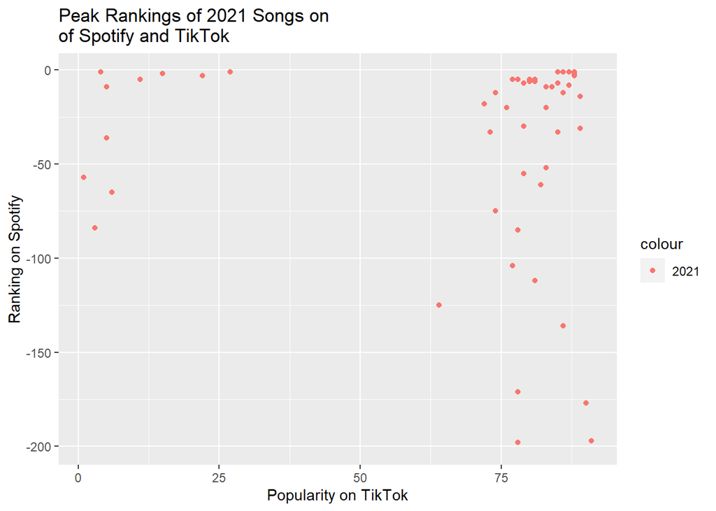

This first chart displays the relationship between the popularity of songs on TikTok vs. on Spotify in 2021. The data comes from a table which contains songs that are popular on both TikTok and Spotify separately which are then organized and plotted using ggplot. We included this chart because we can directly compare how popular songs are on TikTok and on Spotify just by looking at the graph. In the future we can use an interactive graph like plotly so that we can hover over points and see their exact values. We can also consider filtering this data to be focused on a certain artist, or range of peak ranks if we need that information later on.

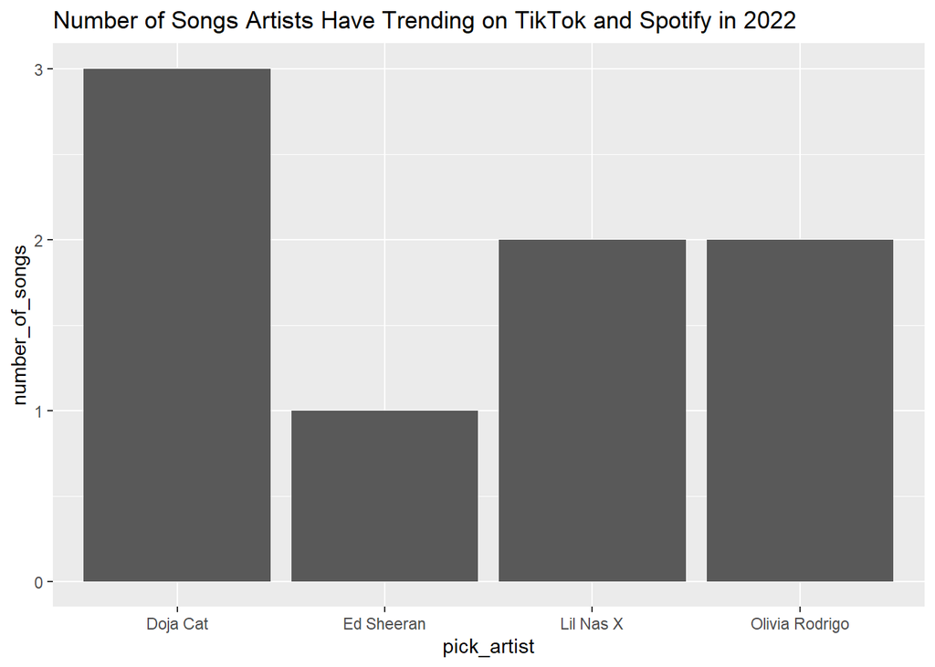

The second chart displays the relationship between an artist and the amount of songs they have that are popular on both Spotify and Tiktok in 2022. We can see that Doja Cat has the most trending songs in this case while Ed Sheeran has the least. We included this graph because it is important to note the artists whose songs do well on both Spotify and TikTok. Are these artists similar or different in anyway? In the future, we can implement a toggle feature so that we can choose which artists we want to compare in the visualization as well as possibly include the names of the songs that the artists have trending.

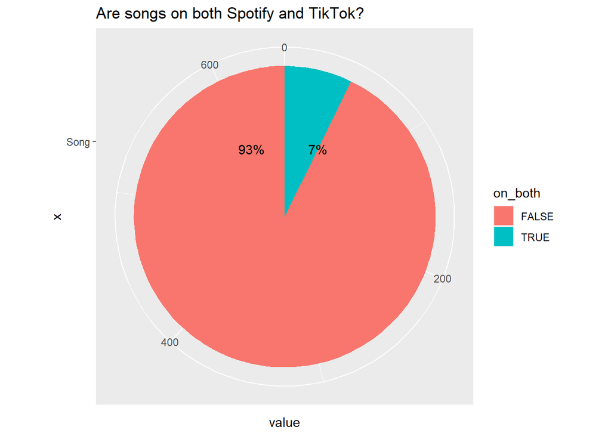

The third and last chart considers whether songs are on both Spotify and TikTok. The results showed that 93% of songs are not on both Spotify and Tiktok while 7% are. This is helpful information because it answers the question, are the same songs popular/trending on TikTok and Spotify? We may consider diving deeper into the 7% in P3 and trying to find what these songs are, who wrote them, and if they have anything in common.

# References

- Acclaim. (2020, June 10). 6 viral TikTok songs that changed artists’ lives. Acclaim Magazine. Retrieved November 15, 2022, from https://acclaimmag.com/music/6-viral-tiktok-songs-that-changed-artists-lives/#11
- Andry, C. S. (n.d.). Dear tiktokers, dancing to trends does not equal celebrity status. Three Penny Press. Retrieved November 15, 2022, from https://threepennypress.org/opinions/2021/11/05/dear-tiktokers-dancing-to-trends-does-not-equal-celebrity-status/#:~:text=Gaining%20a%20lot%20of%20followers,not%20make%20these%20influencers%20celebrities.
- Mitchell-Hardt, A. (2022, October 23). Do tiktok views lead to Spotify streams? Six things every artist needs to know. Playlist Push. Retrieved November 15, 2022, from https://playlistpush.com/blog/do-tiktok-views-lead-to-spotify-streams-four-things-every-artist-needs-to-know/

# Appendix A: Questions

- Are the suggestions for the future we made for the charts feasible?
- We wanted to take a look at how popular older songs or remixes of older songs are on TikTok and on spotify but the only way we filter those songs is manually. Would this be ok if we just looked at around 50-100 rows?